# Concepts and Implementation in R

### Reading the data

```r
library("survival")
data(stanford2)
```

[output not shown]

```r
head(stanford2)
```

|  | id | time | status | age | t5 |
| --- | --- | --- | --- | --- | --- |
| 139 | 139 | 86 | 1 | 12 | 1.26 |
| 159 | 159 | 10 | 1 | 13 | 1.49 |
| 181 | 181 | 60 | 0 | 13 | NA |
| 119 | 119 | 1116 | 0 | 14 | 0.54 |
| 74 | 74 | 2006 | 0 | 15 | 1.26 |
| 120 | 120 | 1107 | 0 | 18 | 0.25 |

```r
NA
```

### Making a factor variable related to the Age > 40

```r
heart <- subset(stanford2, t5 != "NA")
Over40 <- ifelse(heart$age > 40,1,0)
heart <- cbind(heart, Over40)
```

### Making a factor variable related to T5 mismatchlevel 0,1,2

```r
len <- length(heart$t5)

misMatchLevel <- rep(0,len)

for (i in 1:len){

  if (heart$t5[i] > max(heart$t5)/3*2){

    misMatchLevel[i] <- 2

  }else if(heart$t5[i] > max(heart$t5)/3) {

    misMatchLevel[i] <- 1
  }

}

heart <- cbind(heart, misMatchLevel)

heart$misMatchLevel <- as.factor(heart$misMatchLevel)
```

### summary of the data

```r
summary(heart)
```

```
       id              time            status            age              t5
 Min.   :  1.00   Min.   :   0.5   Min.   :0.0000   Min.   :12.00   Min.   :0.000
 1st Qu.: 43.00   1st Qu.:  65.0   1st Qu.:0.0000   1st Qu.:36.00   1st Qu.:0.690
 Median : 83.00   Median : 468.0   Median :1.0000   Median :44.00   Median :1.040
 Mean   : 83.62   Mean   : 769.2   Mean   :0.6497   Mean   :41.73   Mean   :1.117
 3rd Qu.:123.00   3rd Qu.:1264.0   3rd Qu.:1.0000   3rd Qu.:49.00   3rd Qu.:1.460
 Max.   :174.00   Max.   :3695.0   Max.   :1.0000   Max.   :64.00   Max.   :3.050
     Over40       misMatchLevel
 Min.   :0.0000   0:76
 1st Qu.:0.0000   1:70
 Median :1.0000   2:11
 Mean   :0.6306
 3rd Qu.:1.0000
 Max.   :1.0000
```

### Comparing KM curves

```r
knitr::include_graphics("1.PNG")
```

[output not shown]

```r
longrank <- survdiff(Surv(heart$time,heart$status)~ heart$Over40)
longrank
```

```
Call:
survdiff(formula = Surv(heart$time, heart$status) ~ heart$Over40)

                N Observed Expected (O-E)^2/E (O-E)^2/V
heart$Over40=0 58       30     41.9      3.40      5.85
heart$Over40=1 99       72     60.1      2.38      5.85

 Chisq= 5.9  on 1 degrees of freedom, p= 0.02
```

como el valor de la p < 0.05, se rechaza la hipotesis nula, entonce hay evidencia para decir que las 2 funciones de supervivencia son difrentes para los 2 grupos de edad ignorando cualquier otro factor

```r
knitr::include_graphics("2.PNG")
```

[output not shown]

```r
knitr::include_graphics("3.PNG")
```

[output not shown]

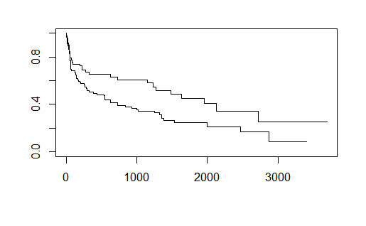

```r
ekm <- survfit(Surv(heart$time,heart$status)~ heart$Over40)
plot(ekm)
```

```r
knitr::include_graphics("4.PNG")
```

[output not shown]

```r
knitr::include_graphics("5.PNG")
```

[output not shown]

No se sabe el valor de la linea base, no se puede calcular el hazard de un individuo en un punto particular porque no tenemos ese valor

```r
knitr::include_graphics("6.PNG")
```

[output not shown]

```r
cox <- coxph(Surv(heart$time,heart$status) ~ heart$Over40)
summary(cox)
```

```
Call:
coxph(formula = Surv(heart$time, heart$status) ~ heart$Over40)

  n= 157, number of events= 102

               coef exp(coef) se(coef)     z Pr(>|z|)
heart$Over40 0.5228    1.6868   0.2185 2.393   0.0167 *
---
Signif. codes:
0 ‘***’ 0.001 ‘**’ 0.01 ‘*’ 0.05 ‘.’ 0.1 ‘ ’ 1

             exp(coef) exp(-coef) lower .95 upper .95
heart$Over40     1.687     0.5929     1.099     2.588

Concordance= 0.551  (se = 0.027 )
Likelihood ratio test= 6.09  on 1 df,   p=0.01
Wald test            = 5.73  on 1 df,   p=0.02
Score (logrank) test = 5.85  on 1 df,   p=0.02
```

En un isntante datado, el logaritmo del riesgo instantaneo de muerte es 0.52 mas alto para los mayores de 40 que para lo menos a esa edad.

```r
knitr::include_graphics("7.PNG")
```

[output not shown]

el harzard ratio es el exponente del coef en este caso 1.69, ignorando cualquier otra variable

```r
knitr::include_graphics("8.PNG")
```

[output not shown]

los test nos muestran que todos nuestro modelos los B no son iguales a 0, nuestro modelo esstastitic with linear regression, todos son mnor a 0.05

```r
cox2 <- coxph(Surv(heart$time,heart$status) ~ heart$Over40 +heart$misMatchLevel)
summary(cox2)
```

```
Call:
coxph(formula = Surv(heart$time, heart$status) ~ heart$Over40 +
    heart$misMatchLevel)

  n= 157, number of events= 102

                       coef exp(coef) se(coef)     z
heart$Over40         0.5452    1.7249   0.2191 2.488
heart$misMatchLevel1 0.1275    1.1360   0.2083 0.612
heart$misMatchLevel2 0.7548    2.1272   0.3896 1.937
                     Pr(>|z|)
heart$Over40           0.0128 *
heart$misMatchLevel1   0.5404
heart$misMatchLevel2   0.0527 .
---
Signif. codes:
0 ‘***’ 0.001 ‘**’ 0.01 ‘*’ 0.05 ‘.’ 0.1 ‘ ’ 1

                     exp(coef) exp(-coef) lower .95
heart$Over40             1.725     0.5797    1.1227
heart$misMatchLevel1     1.136     0.8803    0.7552
heart$misMatchLevel2     2.127     0.4701    0.9911
                     upper .95
heart$Over40             2.650
heart$misMatchLevel1     1.709
heart$misMatchLevel2     4.565

Concordance= 0.557  (se = 0.032 )
Likelihood ratio test= 9.31  on 3 df,   p=0.03
Wald test            = 9.38  on 3 df,   p=0.02
Score (logrank) test = 9.61  on 3 df,   p=0.02
```

```r
knitr::include_graphics("9.PNG")
```

[output not shown]

```r
anova(cox, cox2, test = "LRT")
```

```
Analysis of Deviance Table
 Cox model: response is  Surv(heart$time, heart$status)
 Model 1: ~ heart$Over40
 Model 2: ~ heart$Over40 + heart$misMatchLevel
   loglik  Chisq Df P(>|Chi|)
1 -448.05
2 -446.44 3.2208  2    0.1998
```

Puesto que el p-values 0.1998 > que 0.05, no se rechaza H0, por lo tanto el modelo que incluye mimatch no es mejor que el modelo mas simple

```r
knitr::include_graphics("10.PNG")
```

[output not shown]

NOTA: cuando p < 0.05, y la variable no es un cofounder, mismatch es un predictor significativo, pero no esta mejorando el cofunding entre x, y, es decir que mithmasth solo nos esta ayudando a ser un mejor predictor, si solo estamos interesados en lso verdaderos confundadores debemos tener encuenta estos efectos

```r
knitr::include_graphics("11.PNG")
```

[output not shown]

El hazard es constante

```r
knitr::include_graphics("12.PNG")
```

[output not shown]

```r
knitr::include_graphics("13.PNG")
```

[output not shown]

```r
knitr::include_graphics("14.PNG")
```

[output not shown]

Cuando se cruzan no es apropiado utilizar el COX PH

```r
knitr::include_graphics("15.PNG")
```

[output not shown]

Se epera ver una linea en el centro pero es aceptable ver un pequeña desviacion

```r
knitr::include_graphics("16.PNG")
```

[output not shown]

```r
knitr::include_graphics("17.PNG")
```

[output not shown]

```r
knitr::include_graphics("18.PNG")
```

[output not shown]